# Intro

This dashboard covers the course materials for the statistics course meetings between Utrecht University and the Rabobank.

Course coordinator: [dr. Gerko Vink](https://www.gerkovink.com)  
Lecturers:  
- [dr. Peter Lugtig](https://www.peterlugtig.com)  
- [prof.dr. Peter van der Heijden](https://www.uu.nl/medewerkers/pgmvanderheijden)  
- [prof.dr. Stef van Buuren](https://stefvanbuuren.name)  
- [prof.dr. Daniel Oberski](https://daob.nl/)  
- [dr. Rebecca Kuiper](https://www.uu.nl/medewerkers/rmkuiper)

We will adapt the course as we go. Therefore we suggest to access the materials online when we consider them.

**Schedule**

| # | Time | Date |
| --- | --- | --- |
| 1 | 9.30 - 12.00 | January 21 |
| 2 | 9.30 - 12.00 | February 11 |
| 3 | 9.30 - 12.00 | March 11 |
| 4 | 9.30 - 12.00 | March 25 |
| 5 | 9.30 - 12.00 | April 8 |

# Overview

### Description

Welcome to this course page.

This page is designed as a dashboard that holds the course materials and meeting links for the meetings on statistics between Utrecht University and the Rabobank.

Please use the tabs above to navigate this page. If there is anything that remains unclear, or if there is a question that you would like to ask me, feel free to contact me.

All the best,

[Gerko Vink](https://www.gerkovink.com)

# Meet the team

### dr. Peter Lugtig

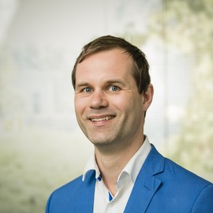

Peter Lugtig is an associate professor at the department of Methodology and Statistics at Utrecht University, where he specializes in survey methodology, which includes inferences using a mix of survey data and big data and the modelling of survey errors, and the use of sensor technology in smartphones.

### prof. dr. Peter van der Heijden

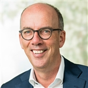

Peter van der Heijden has a chair in statistics for the behavioural and social sciences. His research concerns linkage of registers, population size estimation, randomized response, estimating fraud, and models for the analysis of categorical data. For a variety of Dutch ministries he has carried out contract research in these areas.

### prof.dr. Daniel Oberski

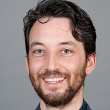

Daniel Oberski is full professor of health and social data science, with a joint appointment at Utrecht University’s Department of Methodology & Statistics, and the department of Biostatistics and Data Science at the Julius Center, University Medical Center Utrecht (UMCU). His research focuses on data science methodology, in particular the problem of measurement in the social and health sciences.

### prof.dr. Stef van Buuren

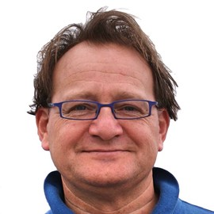

Stef van Buuren is Professor of Statistical Analysis of Incomplete Data at the University of Utrecht and Principal Scientist at the Netherlands Organisation for Applied Scientific Research TNO in Leiden. His interests include the analysis of incomplete data, child growth and development, computational statistics, measurement and individual causal effects.

### dr. Rebecca Kuiper

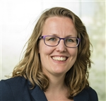

Rebecca Kuiper is an assistant professor at the Department of Methods and Statistics at University Utrecht. I am passionate about doing research in the field of (bio)statistics & psychometrics and behavioural & social sciences

### dr. Gerko Vink

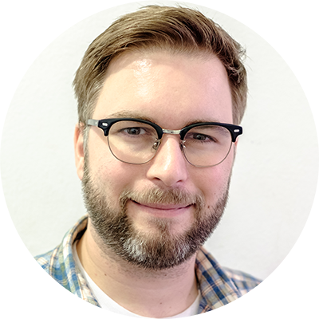

Gerko Vink is a statistician masquerading as a data scientist with a passion for educating people. He has an interest in new developments concerning the presentation of data, results and knowledge. His work focuses on problems where not all data is available (some left in the dark), privacy, computational evaluation and programming. He works as an associate professor at Utrecht University

# Meeting 1

### This meeting

In this meeting, [dr. Peter Lugtig](https://www.peterlugtig.com) will teach us about *Inference and Hypothesis Testing*.

During and after the lecture there will be plenty of room for questions and discussion. To aid the understanding of this meeting’s theory we have prepared a series of exercises for you. You can find all meeting materials in the column to the right.

**THIS IS THE MEETING LINK FOR THE FIRST MEETING**

### Meeting schedule

| When? |  | What? |
| --- | --- | --- |
| 09.30 | 09.45 | Introduction |
| 09.45 | 11.15 | Lecture |
| 11.15 | 11.30 | Discussion |
| 11.30 | 12.00 | Set up for next meeting |

We will reserve plenty of room for breaks.

### Other useful links

Please find here any useful links relating to this meeting’s materials

### Lecture slides

Please find the lecture slides and relevant materials below:

- Slides on Inference and Hypothesis testing

### Exercises in JASP

[JASP](https://jasp-stats.org) is an open-source statistics processor aimed at provinding an easy to use intuitive interface for standard analysis procedures. If you have little experience with statistics and programming, we recommend following the exercises in JASP.

- Introduction to JASP
- Regression in JASP
- The mammalsleep data for the challenge (right-click to save)
- [Video discussion of the challenge](https://www.dropbox.com/s/rr2aiz12tjswj4c/Challenge_JASP.mp4?dl=0)

If you have questions about the exercises, please contact Gerko Vink

### Exercises in `R`

[`R`](https://www.r-project.org) is a free software environment that serves as the de facto standard for statistical computing and graphics. If you have experience with statistics and programming, we recommend following the exercises in `R`.

- Introduction to `R`
- Regression in `R`
- My output for the challenge
- [Video discussion of the challenge](https://www.dropbox.com/s/m9hb4xmdac4ufvz/Challenge_R.mp4?dl=0)

If you have questions about the exercises, please contact Gerko Vink

**Other useful links for the `R` exercises:**

- For those that are not yet familiar with `R`, Gerko Vink has developed [this course including video walkthroughs](https://www.gerkovink.com/prepR/#exercises) aimed at getting participants jump-started with scripting in `R`. This course is also referred to in the Introduction to `R`.
- [The tidyverse style guide](https://style.tidyverse.org)

# Meeting 2

### This meeting

In this meeting, [Prof. dr. Peter van der Heijden](https://www.uu.nl/medewerkers/pgmvanderheijden) will teach us about *Prediction and effect sizes*.

During and after the lecture there will be plenty of room for questions and discussion. To aid the understanding of this meeting’s theory we have prepared a series of exercises for you. You can find all meeting materials in the column to the right.

**THIS IS THE MEETING LINK FOR THE SECOND MEETING**

### Meeting schedule

| When? |  | What? |
| --- | --- | --- |
| 09.30 | 09.45 | Introduction |
| 09.45 | 11.15 | Lecture |
| 11.15 | 11.30 | Discussion |
| 11.30 | 12.00 | Set up for next meeting |

We will reserve plenty of room for breaks.

### Other useful links

Please find here any useful links relating to this meeting’s materials

### Lecture slides

Please find the lecture slides and relevant materials below:

- Slides for this meeting

### Exercises in JASP

[JASP](https://jasp-stats.org) is an open-source statistics processor aimed at provinding an easy to use intuitive interface for standard analysis procedures. If you have little experience with statistics and programming, we recommend following the exercises in JASP.

- Exercise in JASP

If you have questions about the exercises, please contact Gerko Vink

### Exercises in `R`

[`R`](https://www.r-project.org) is a free software environment that serves as the de facto standard for statistical computing and graphics. If you have experience with statistics and programming, we recommend following the exercises in `R`.

- Exercise in `R`
- A document that simulates prediction and confidence intervals; both obtained parametrically and via the bootstrap.

If you have questions about the exercises or any of the other documents, please contact Gerko Vink

# Meeting 3

### This meeting

In this meeting, [Prof. dr. Daniel Oberski](https://daob.nl) will teach us about *Classification*.

During and after the lecture there will be plenty of room for questions and discussion. To aid the understanding of this meeting’s theory we have prepared a series of exercises for you. You can find all meeting materials in the column to the right.

**THIS IS THE MEETING LINK FOR THE THIRD MEETING**

### Meeting schedule

| When? |  | What? |
| --- | --- | --- |
| 09.30 | 09.45 | Introduction |
| 09.45 | 11.15 | Lecture |
| 11.15 | 11.30 | Discussion |
| 11.30 | 12.00 | Set up for next meeting |

We will reserve plenty of room for breaks.

### Other useful links

Please find here any useful links relating to this meeting’s materials

### Lecture slides

Please find the lecture slides and relevant materials below:

- Slides for this meeting

### Exercises in JASP

[JASP](https://jasp-stats.org) is an open-source statistics processor aimed at provinding an easy to use intuitive interface for standard analysis procedures. If you have little experience with statistics and programming, we recommend following the exercises in JASP.

- Exercise in JASP
- [video discussion of the exercise](https://www.dropbox.com/s/6xyn000mw49w890/jasp-recording.mp4?dl=0)

If you have questions about the exercises, please contact Gerko Vink

### Exercises in `R`

[`R`](https://www.r-project.org) is a free software environment that serves as the de facto standard for statistical computing and graphics. If you have experience with statistics and programming, we recommend following the exercises in `R`.

- Exercise in `R`
- [video discussion of the exercise](https://www.dropbox.com/s/cl7ehkny5ome61g/r-recording.mp4?dl=0)
- [A great blog](https://blog.revolutionanalytics.com/2016/03/com_class_eval_metrics_r.html) about manually calculating some of the discussed evaluation metrics in `R`.

If you have questions about the exercises or any of the other documents, please contact Gerko Vink

### In `bigML`

We use generic machine learning data sets in our exercises. The train of thought in the exercises therefore closely resembles parts of [this online training](http://training.bigml.com) by `bigML`. Some of you have access to this platform, already. With `bigML` you can simply apply and evaluate a selection of machine learning algorithms in a standardized framework. For this you do not need any coding experience.

- Exercise in `bigML`. This is the JASP exercise mimicked in `bigML`, with K-Means clustering instead of KNN classification.

# Meeting 4

### This meeting

In this meeting, [Prof. dr. Stef van Buuren](https://stefvanbuuren.name) will teach us about *dark data, imputation and data synthesis*.

During and after the lecture there will be plenty of room for questions and discussion. To aid the understanding of this meeting’s theory we have prepared a series of exercises for you. You can find all meeting materials in the column to the right.

**THIS IS THE MEETING LINK FOR THE FOURTH MEETING**

### Meeting schedule

| When? |  | What? |
| --- | --- | --- |
| 09.30 | 10.15 | Lecture 1 |
| 10.30 | 11.15 | Lecture 2 |
| 11.30 | 12.00 | Lecture 3 and set-up for final meeting |

### Other useful links

Our group works hard on the development and dissemination of incomplete data methods and methods of data synthesis. You may consider the following links

- [Flexible imputation of missing data](https://stefvanbuuren.name/fimd/) book by Stef van Buuren
- [our group’s GitHub organization](https://github.com/amices)
- [A publication detailing the workflow of data synthesis in `mice`](https://www.mdpi.com/2624-8611/3/4/45) with simulation proofs of its validity.
- [A paper about imputing a finite population](https://doi.org/10.1515/jos-2017-0045)

### Lecture slides

Please find the lecture slides and relevant materials below:

- Slides for this meeting
- Handout of the slides

### Exercise with ShinyMice

[JASP](https://jasp-stats.org) does not yet allow for data imputation. To get a feeling about imputing and inspecting incomplete data with `mice` in `R` without having to know `R`, we have developed `ShinyMice`. With `ShinyMice`, users can generate, inspect and evaluate incomplete data imputations in the browser. I (Gerko) walk you through the possibilities and evaluations that `ShinyMice` offers.

- [The `ShinyMice` site](https://hanneoberman.shinyapps.io/shinymice-demo/) and [project site](https://amices.org/shinymice/)
- [Walkthrough of `ShinyMice`](https://www.dropbox.com/s/r2njkn56hqph5wy/shinymice.mp4?dl=0)

If you have questions about the exercises, please contact Gerko Vink. For questions and suggestions about the workings of `ShinyMice`, please contact [Hanne Oberman](https://hanneoberman.github.io).

### Exercises in `R`

[`R`](https://www.r-project.org) is a free software environment that serves as the de facto standard for statistical computing and graphics. If you have experience with statistics and programming, we recommend following the exercises in `R`.

- [Exercise in `R`](https://www.gerkovink.com/quickmice/)
- Generating synthetic data sets with `mice`

If you have questions about the exercises or any of the other documents, please contact Gerko Vink

# Final meeting

### This meeting

In this meeting, [Gerko Vink](https://www.gerkovink.com) will close the series with a retrospect about the course and some of the core uncertainty principles that were covered. He will also discuss a simulation-based and a reasoning-based solution to scenarios where no comparative truth exists.

This meeting is also the time to pick our brains. So we ask you to

1. Create a short presentation about a practical or conceptual scenario in your work (i.e. one or two slides).
2. This scenario may be data-based, information-based, problem-based, etcetera.
3. The scenario may be real, data-based, simulated or even hypothetical, but you must be able to describe it.

If you find it challenging to identify a scenario in the context of this course, than that can also be your scenario. If you’d like some input beforehand or if you’d like to discuss this, feel free to approach me (Gerko).

During and after the lecture there will be plenty of room for questions and discussion..

**THIS IS THE MEETING LINK FOR THE FINAL MEETING**

### Meeting schedule

| When? |  | What? |
| --- | --- | --- |
| 09.30 | 10.30 | Lecture |
| 10.45 | 12.00 | Real-world case discussion |

### Lecture slides

Please find the lecture slides and relevant materials below:

- Slides for this meeting